# EMOS Assignment of Big Data

## Serial processing

```r
# seed for reproducibility
set.seed(1128)

# bootstrap iterations
n_bootstraps <- 10000

# data
data <- read.csv("mtcars.csv", header = TRUE, sep = ";")

# IDA
knitr::kable(head(data))
```

| mpg | cyl | disp | hp | drat | wt | qsec | vs | am | gear | carb |
| --- | --- | --- | --- | --- | --- | --- | --- | --- | --- | --- |
| 21.0 | 6 | 160 | 110 | 3.90 | 2.620 | 16.46 | 0 | 1 | 4 | 4 |
| 21.0 | 6 | 160 | 110 | 3.90 | 2.875 | 17.02 | 0 | 1 | 4 | 4 |
| 22.8 | 4 | 108 | 93 | 3.85 | 2.320 | 18.61 | 1 | 1 | 4 | 1 |
| 21.4 | 6 | 258 | 110 | 3.08 | 3.215 | 19.44 | 1 | 0 | 3 | 1 |
| 18.7 | 8 | 360 | 175 | 3.15 | 3.440 | 17.02 | 0 | 0 | 3 | 2 |
| 18.1 | 6 | 225 | 105 | 2.76 | 3.460 | 20.22 | 1 | 0 | 3 | 1 |

```r
knitr::kable(summary(data))
```

|  | mpg | cyl | disp | hp | drat | wt | qsec | vs | am | gear | carb |
| --- | --- | --- | --- | --- | --- | --- | --- | --- | --- | --- | --- |
|  | Min. :10.40 | Min. :4.000 | Min. : 71.1 | Min. : 52.0 | Min. :2.760 | Min. :1.513 | Min. :14.50 | Min. :0.0000 | Min. :0.0000 | Min. :3.000 | Min. :1.000 |
|  | 1st Qu.:15.43 | 1st Qu.:4.000 | 1st Qu.:120.8 | 1st Qu.: 96.5 | 1st Qu.:3.080 | 1st Qu.:2.581 | 1st Qu.:16.89 | 1st Qu.:0.0000 | 1st Qu.:0.0000 | 1st Qu.:3.000 | 1st Qu.:2.000 |
|  | Median :19.20 | Median :6.000 | Median :196.3 | Median :123.0 | Median :3.695 | Median :3.325 | Median :17.71 | Median :0.0000 | Median :0.0000 | Median :4.000 | Median :2.000 |
|  | Mean :20.09 | Mean :6.188 | Mean :230.7 | Mean :146.7 | Mean :3.597 | Mean :3.217 | Mean :17.85 | Mean :0.4375 | Mean :0.4062 | Mean :3.688 | Mean :2.812 |
|  | 3rd Qu.:22.80 | 3rd Qu.:8.000 | 3rd Qu.:326.0 | 3rd Qu.:180.0 | 3rd Qu.:3.920 | 3rd Qu.:3.610 | 3rd Qu.:18.90 | 3rd Qu.:1.0000 | 3rd Qu.:1.0000 | 3rd Qu.:4.000 | 3rd Qu.:4.000 |
|  | Max. :33.90 | Max. :8.000 | Max. :472.0 | Max. :335.0 | Max. :4.930 | Max. :5.424 | Max. :22.90 | Max. :1.0000 | Max. :1.0000 | Max. :5.000 | Max. :8.000 |

```r
set.seed(1128)
bootstrap_iteration <- function(data) {
  # Sample with replacement
  boot_sample <- data[sample(nrow(data), replace = TRUE), ]

  # model fitting
  model <- lm(mpg ~ wt + disp, data = boot_sample)

  # R-squared
  rsq <- summary(model)$r.squared

  return(rsq)
}
```

```r
# Serial processing
results <- numeric(n_bootstraps)

# starting time
start_time <- Sys.time()

for (i in 1:n_bootstraps) {
  results[i] <- bootstrap_iteration(data)
}

# end time
end_time <- Sys.time()

total_time <- end_time - start_time
print(paste("Total time:", total_time))
```

```
## [1] "Total time: 3.19999885559082"
```

```r
# summary statistics
summary_stats <- summary(results)
print(summary_stats)
```

```
##    Min. 1st Qu.  Median    Mean 3rd Qu.    Max.
##  0.4258  0.7636  0.7966  0.7927  0.8267  0.9484
```

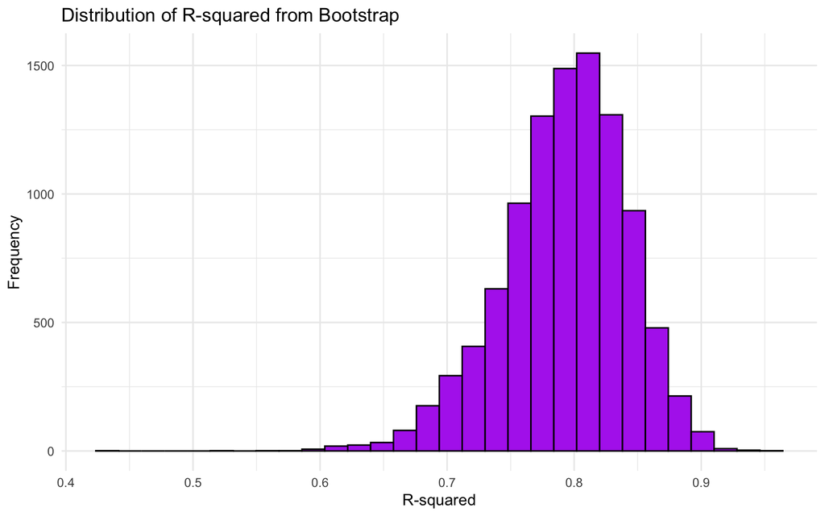

```r
# histogram of bootstrap results
ggplot(data.frame(r_squared = results), aes(x = r_squared)) +
  geom_histogram(bins = 30, fill = "darkorchid2", color = "black") +
  labs(title = "Distribution of R-squared from Bootstrap",
       x = "R-squared",
       y = "Frequency") +
  theme_minimal()
```

```r
# 95% CI
ci <- quantile(results, c(0.025, 0.975))
print(paste("95% Confidence Interval:", ci[1], "-", ci[2]))
```

```
## [1] "95% Confidence Interval: 0.685406027491677 - 0.877444559038747"
```

Interpretation:

- There’s a roughly normal distribution of R-squared values, with a slight negative skew. The relationship between the predictors and the response variable (miles per gallon) is relatively stable across bootstrap samples.
- The mean and median are very close, supporting the observation of an approximately symmetric distribution. About 79% of the variance in mpg can be explained by weight and displacement in the average bootstrap sample.
- The model consistently explains a substantial portion of the variance in mpg, with even the lower bound of the confidence interval suggesting a moderate relationship ([0.6854, 0.8774]). However, this wide range reflects uncertainty in the exact strength of the relationship, possibly due to the small sample size of the mtcars data (only 32 cases).